# Practical Machine Learning Project

James Eddy

September 20, 2014

### Summary

The objective of this project was to predict “classes” of exercise performance (correct: class `A`, or 1 of 4 common mistakes: class `B-E`) for subjects performing barbell lifts. A random forest model was trained on 13 variables in the data (selected based on “importance” in training the classifier), and this model performed exceptionally well on classifiying subjects in the independent test data.

#### Packages used

```r
library(caret)
library(randomForest)
library(dplyr)
```

### Accessing & loading the data

The training and testing CSV data files were downloaded directly from the provided links. Both files were saved in the `data` directory.

```r
# Create new directory to store data
if (!file.exists("data/")) {
    dir.create("data/")
}

# Specify base URL for files
fileBase <- "https://d396qusza40orc.cloudfront.net/predmachlearn/"

# Download training data
trainAddress <- paste0(fileBase, "pml-training.csv")
download.file(trainAddress, "data/pmlTraining.csv", method = "curl")

# Download test data
testAddress <- paste0(fileBase, "pml-testing.csv")
download.file(testAddress, "data/pmlTesting.csv", method = "curl")

# Record the date of data access
downloadDate <- date()
```

For the analysis and results presented in this report, the data used was accessed and downloaded on **Mon May 16 13:01:06 2016**. After loading the data into `R`, I used the `str()` function to inspect the variables in the training data.

```r
# Load the data
training <- read.csv("data/pmlTraining.csv")
testing <- read.csv("data/pmlTesting.csv")

# Inspect the training data
str(training)
```

### Cleaning the data

The output of `str()` (and visually inspecting the training data with `View()` highlighted that a number of variables included many missing values or NAs. To simplify classifier training and ease computation for more complex machine learning algorithms, I chose to remove these variables, as well as any with near-zero-variance, as identified with the `nearZeroVar()` function. I also removed any variables pertaining to more record-keeping type information about the measurements (e.g., entry number, user name, time of recording), rather than actual measurement values. These variables shouldn’t correspond to class, and might not even be available for all future samples, and therefore would not be helpful for training classifiers. The one exception to this logic is the variable `X`, which is essentially just the entry or row number; this variable is clearly correlated with class (as the rows are not randomized in any way), but has no real relationship with exercise performance. The reduced training data was stored in the `trainingComplete` object.

```r
# Drop non-measurement columns
training <- training %>%
    select(-X, -user_name, -raw_timestamp_part_1, -raw_timestamp_part_2,
           -cvtd_timestamp, -new_window, -num_window)

# Drop any variables with missing values, NAs, or near-zero variance
missingVars <- (colSums(is.na(training) | training == "") != 0)
missingIdx <- seq(1, ncol(training), 1)[missingVars]
nzv <- nearZeroVar(training)
trainingComplete <- training[, -union(missingIdx, nzv)]
```

### Selecting a model

I first partitioned the training data into smaller training (70% of samples) and test (30% of samples) sets for building and testing models. I built a random forest classifier using the `subTrain` data and evaluated the accuracy of this model on `subTest` sample classes. Note: the `set.seed()` function was used to help make the analysis reproducible.

```r
set.seed(1234)
inTrain = createDataPartition(trainingComplete$classe, p = 0.7)[[1]]
subTrain <- trainingComplete[inTrain, ]
subTest <- trainingComplete[-inTrain, ]

rfModel <- randomForest(classe ~ ., data = subTrain, importance = TRUE)
classePred <- predict(rfModel, newdata = subTest)
confusionMatrix(data = classePred, reference = subTest$classe)
```

```
## Confusion Matrix and Statistics
##
##           Reference
## Prediction    A    B    C    D    E
##          A 1674    6    0    0    0
##          B    0 1132    6    0    0
##          C    0    1 1020    4    0
##          D    0    0    0  959    0
##          E    0    0    0    1 1082
##
## Overall Statistics
##
##                Accuracy : 0.9969
##                  95% CI : (0.9952, 0.9982)
##     No Information Rate : 0.2845
##     P-Value [Acc > NIR] : < 2.2e-16
##
##                   Kappa : 0.9961
##  Mcnemar's Test P-Value : NA
##
## Statistics by Class:
##
##                      Class: A Class: B Class: C Class: D Class: E
## Sensitivity            1.0000   0.9939   0.9942   0.9948   1.0000
## Specificity            0.9986   0.9987   0.9990   1.0000   0.9998
## Pos Pred Value         0.9964   0.9947   0.9951   1.0000   0.9991
## Neg Pred Value         1.0000   0.9985   0.9988   0.9990   1.0000
## Prevalence             0.2845   0.1935   0.1743   0.1638   0.1839
## Detection Rate         0.2845   0.1924   0.1733   0.1630   0.1839
## Detection Prevalence   0.2855   0.1934   0.1742   0.1630   0.1840
## Balanced Accuracy      0.9993   0.9963   0.9966   0.9974   0.9999
```

With default parameters, the random forest classifier trained with 500 trees achieved over **99%** accuracy when predicting exercise class in of `subTest` samples. In the hopes of building a more parsimonious classifier (and reducing computational time), I examined the relative importance of all variables, as measured during the random forest training procedure. As shown in the histogram below, there is a rational separation in variable importance for a value of around **250** for mean decrease in Gini coefficient.

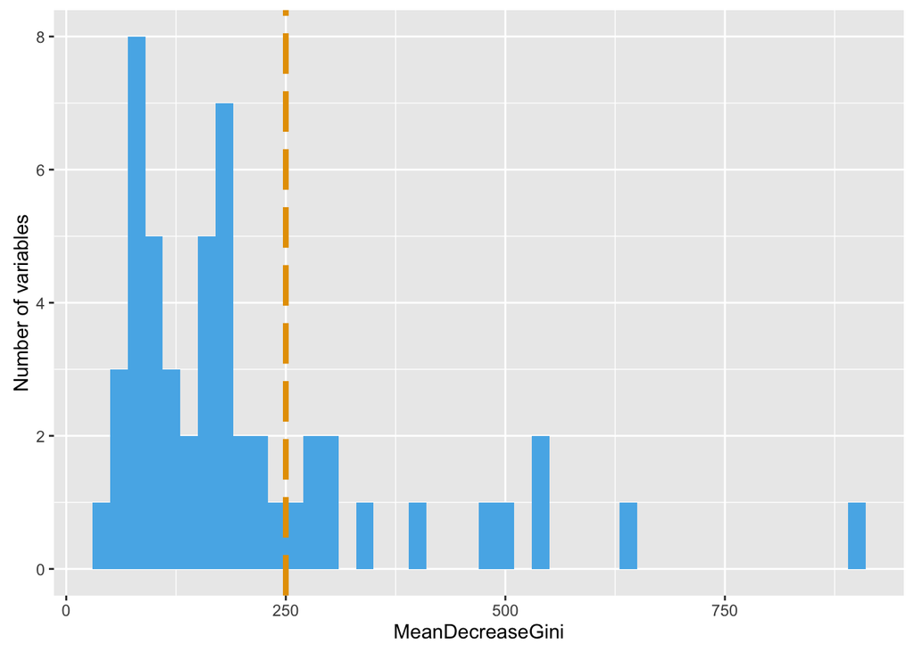

```r
varImportance <- as.data.frame(importance(rfModel))
varImportance %>%
    ggplot(aes(x = MeanDecreaseGini)) +
    geom_histogram(binwidth = 20, fill = "#56B4E9") +
    geom_vline(xintercept = 250, colour = "#E69F00", size = 1.5,
               linetype = "longdash") +
    ylab("Number of variables")
```

```r
importantVars <- row.names(varImportance)[varImportance$MeanDecreaseGini > 250]
```

When I trained a new classifier using only the top **13** variables (those with Gini decrease > 250), accuracy was still very high, with a significant drop in computation time.

```r
rfModelImp <- randomForest(classe ~ .,
                        data = subTrain[, names(subTrain) %in%
                                            c(importantVars, "classe")])
classePred <- predict(rfModelImp, newdata = subTest)
confusionMatrix(data = classePred, reference = subTest$classe)
```

```
## Confusion Matrix and Statistics
##
##           Reference
## Prediction    A    B    C    D    E
##          A 1670   14    3    0    0
##          B    2 1107   10    1    6
##          C    1    7 1006    3    5
##          D    1   11    7  960    5
##          E    0    0    0    0 1066
##
## Overall Statistics
##
##                Accuracy : 0.9871
##                  95% CI : (0.9839, 0.9898)
##     No Information Rate : 0.2845
##     P-Value [Acc > NIR] : < 2.2e-16
##
##                   Kappa : 0.9837
##  Mcnemar's Test P-Value : NA
##
## Statistics by Class:
##
##                      Class: A Class: B Class: C Class: D Class: E
## Sensitivity            0.9976   0.9719   0.9805   0.9959   0.9852
## Specificity            0.9960   0.9960   0.9967   0.9951   1.0000
## Pos Pred Value         0.9899   0.9831   0.9843   0.9756   1.0000
## Neg Pred Value         0.9990   0.9933   0.9959   0.9992   0.9967
## Prevalence             0.2845   0.1935   0.1743   0.1638   0.1839
## Detection Rate         0.2838   0.1881   0.1709   0.1631   0.1811
## Detection Prevalence   0.2867   0.1913   0.1737   0.1672   0.1811
## Balanced Accuracy      0.9968   0.9840   0.9886   0.9955   0.9926
```

### Evaluating the model

To estimate the potential out-of-sample error with the chosen random forest classifier, I used a 10-fold cross-validation procedure and calculated the mean classification accuracy on test samples across all folds. As the 13 important variables used to train classifiers were learned from the `subTrain` samples, I used only the `subTest` samples for cross validation.

```r
nFolds <- 10
cvFolds <- createFolds(subTest$classe, k = nFolds)
foldAcc <- rep(0, nFolds)

for (fold in 1:nFolds) {
    foldTrain <- subTest[-cvFolds[[fold]],
                                 names(subTest) %in%
                                     c(importantVars, "classe")]
    foldTest <- subTest[cvFolds[[fold]], ]

    foldModel <- randomForest(classe ~., data = foldTrain)
    classePred <- predict(foldModel, newdata = foldTest)

    foldAcc[fold] <- confusionMatrix(data = classePred,
                                     reference = foldTest$classe)$overall[1]
}
```

The cross-validation accuracy achieved with a random forest classifier trained on the most important variables was **0.9651669**, suggesting potentially good performance on new samples.

### Training & validating final classifier

Finally, I used all samples in the training data with the 13 important variables to train my final classification model.

```r
trainingImportant <- trainingComplete[, names(trainingComplete) %in%
                                          c(importantVars, "classe")]
rfModel <- randomForest(classe ~ ., data = trainingImportant)
```

To evaluate the performance of this model, I submitted predictions for exercise classes in the `testing` data to the course website. My classifier correctly predicted **20/20** test sample classes, for 100% accuracy.

```r
# Predict classes in the test data
testPred <- as.character(predict(rfModel, newdata = testing))
```